# Homework 1

## Part O-15

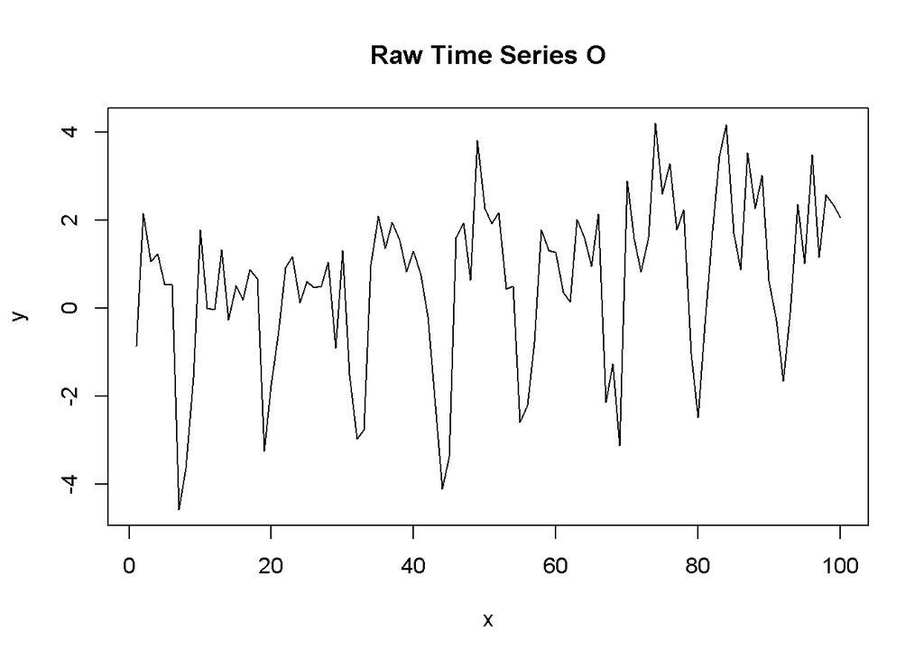

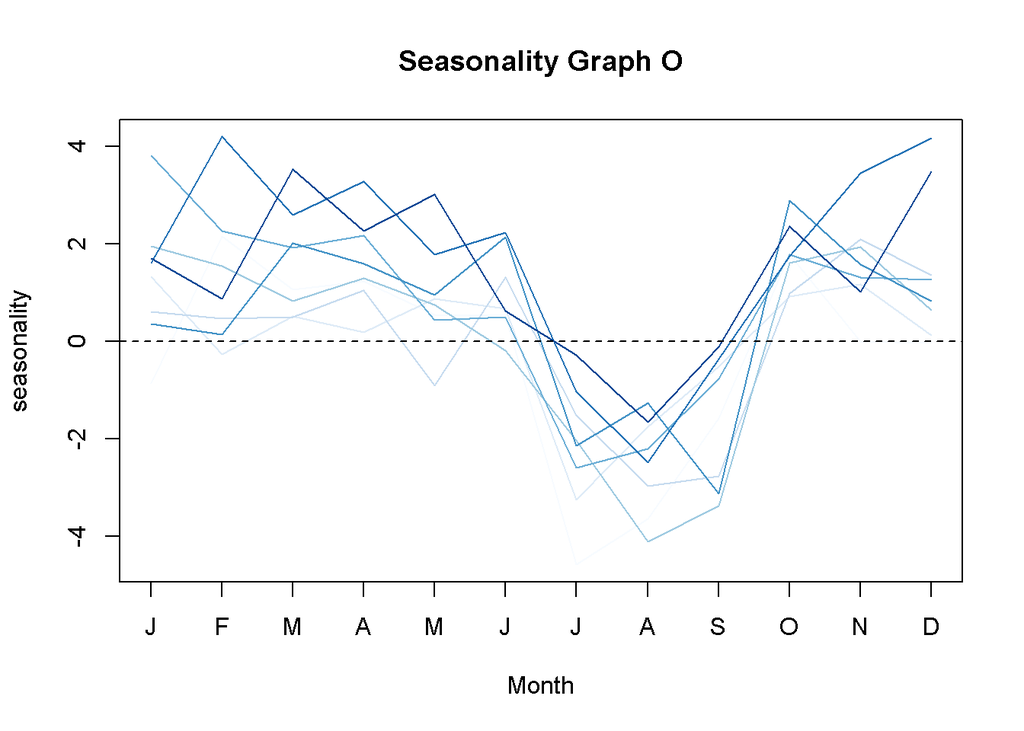

There appears to be a deterministic trend as well as a seasonal effect in the third quarter. After detrending and seasonally adjusting the time series, there does not appear to be anything besides random noise.

**DGP Guess:** deterministic trend, where $\hat{\beta}=0.0219865$ AND Seasonality in Q3 (July, August, September)

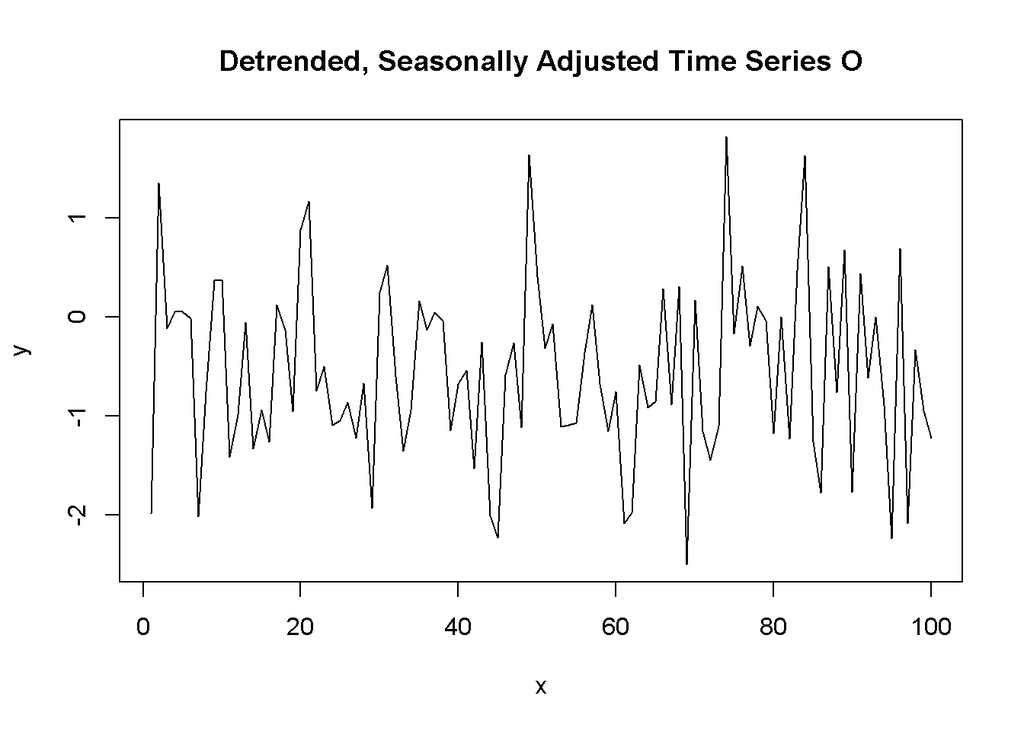

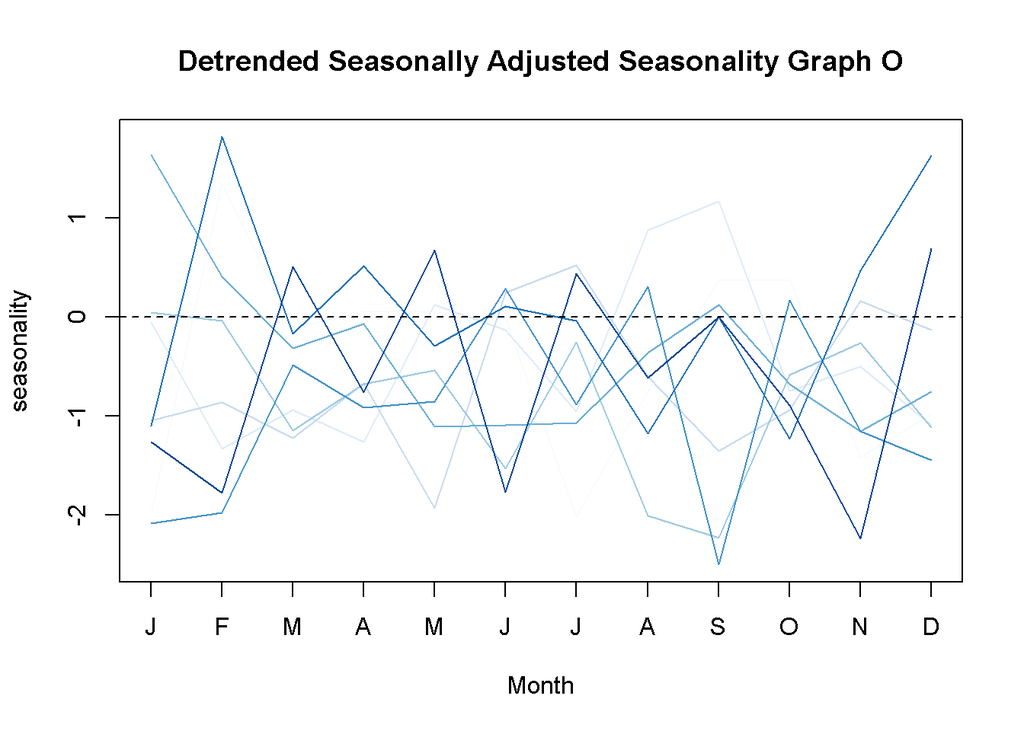

## Part P-16

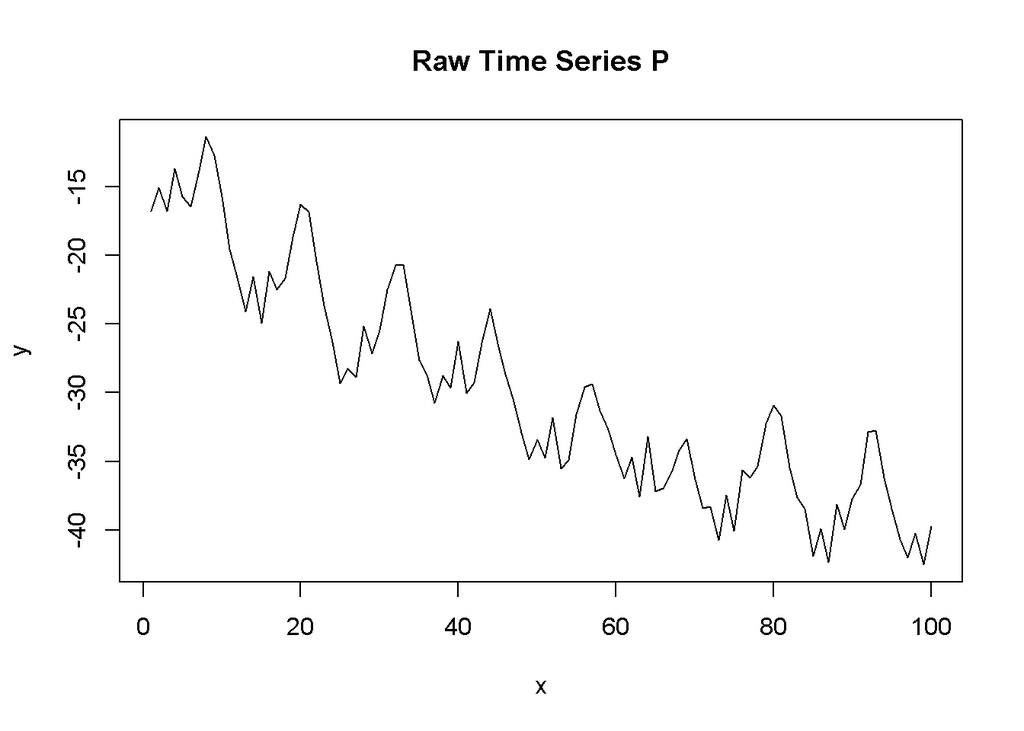

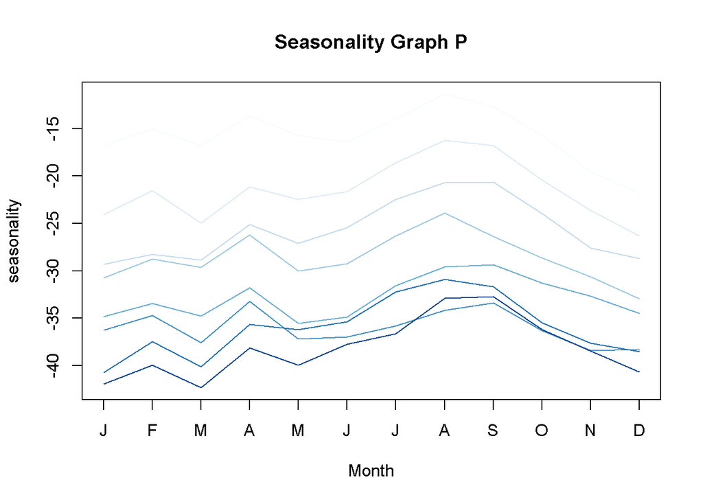

Again we see a a clear deterministic trend as well as a monthly seasonal pattern. After detrending and seasonally adjusting the time series, there also seems to be a first order AR process.

**DGP Guess:** deterministic trend, where $\hat{\beta}=-0.2539671$ AND Monthly seasonality AND AR(1) where $\phi_1=0.9$

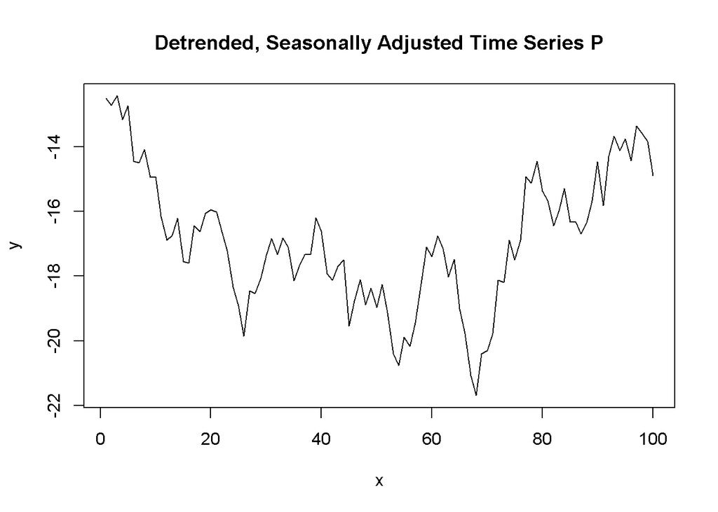

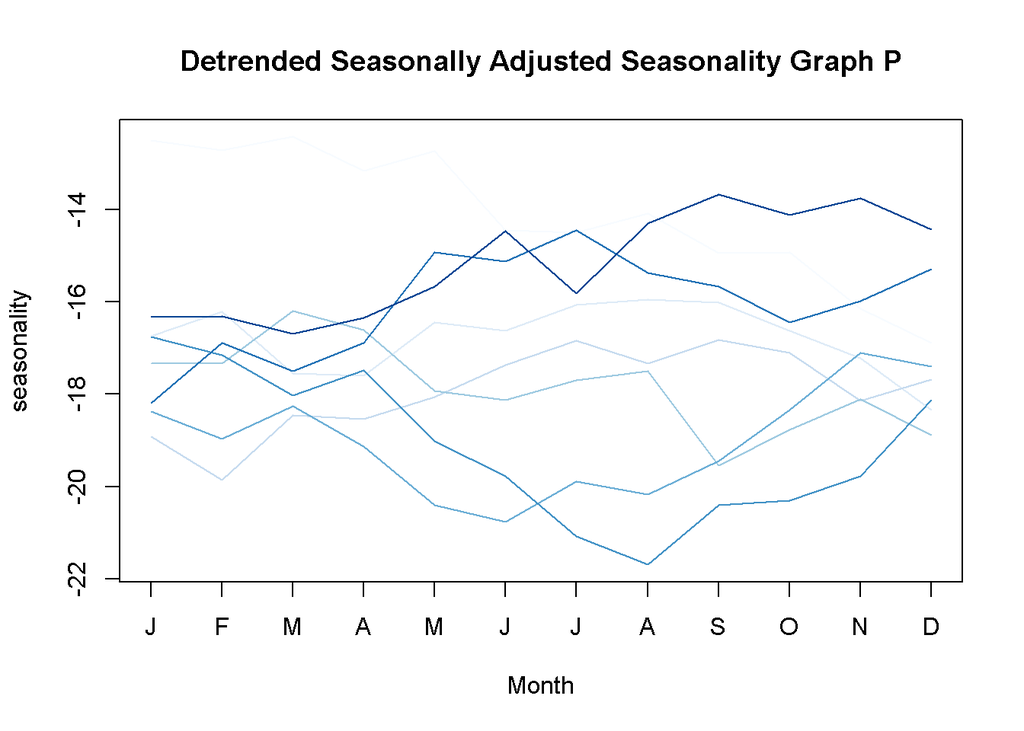